# Week 3: Data Exploration and Visualisation

Zak Varty

## Week In Review

**Data Wrangling**

- Manipulate you data with base R and `{dplyr}`
- Factors, Strings, Dates

**EDA**

- Purpose for you, manager and stakeholder
- Not a prescriptive exercise
- Roger Peng example

**Data Viz**

- Reflect on purpose, audience and medium
- Cédric Scherer ggplot tutorial
- Exercise coming up!

## Which `NormConf` video did you watch and what did you learn from it?

`08:00`

## Other than `ggplot2`, what else have you used to create data visualisations? What are their relative strengths and weaknesses?

`08:00`

## Compare your implementation of `rolling_sd()` with someone else. What conclusions did you draw when applying it to the Dow Jones data?

`08:00`

# Part 2: Writing Alt-text

## Exercise 1: Text to Plot

Split into 5 groups and spread around the room.

Try to draw the plot based on the alt-text provided.

`08:00`

## Exercise 2: Plot to Text

Write your own alt-text based on the plot provided.

`08:00`

## Exercise 3: Text to plot

Pass your alt-text to another group. They have to try and recreate your plot!

`08:00`

# Break! Have ten minuts of hard-earned rest.

> Help me to make this module better:

> www.menti.com `54 08 92 6`

`10:00`

## Putting it all together

Wrangle, explore and visualise! Work alone or in small groups to complete this week’s Tidy Tuesday challenge for yourself.

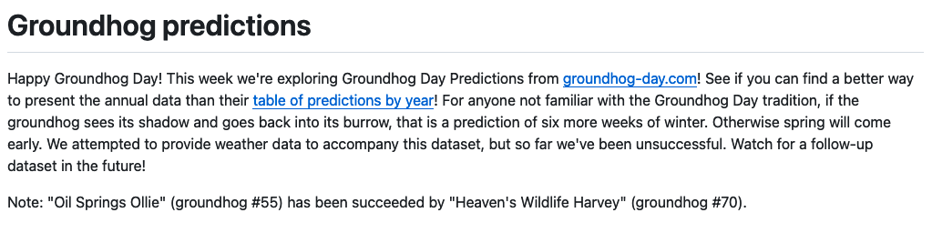

## Getting the data

`https://github.com/rfordatascience/tidytuesday/tree/master/data/2024/2024-01-30`

[figure not shown]

[figure not shown]